# NDVI

## Exploring the NDVI in Philadelphia

The normalized difference vegetation index (NDVI) is a commonly used index that measures the live vegetation coverage in an area in satellite image (remote sensing) analysis. The NDVI index is calculated as The NDVI is calculated from these individual measurements as follows:

NDVI = (NIR - Red)/(NIR + Red),

where red and NIR stand for the spectral reflectance measurements acquired in the red (visible) and near-infrared regions, respectively. In this part, I'll explore the NDVI in Philadelphia with both raster landsat data and vector data with two steps:

1. I'll compare the median NDVI within the city limits and the immediate suburbs
2. I'll calculate the NDVI around street trees in the city.

## 1. Comparing the NDVI in the city and the suburbs

### 1.1 Load Landsat data for Philadelphia

Use rasterio to load the landsat data for Philadelphia (available in the "data/" folder)

```python
import numpy as np
import pandas as pd
import geopandas as gpd
import hvplot.pandas
import holoviews as hv
import cartopy.crs as ccrs
from matplotlib import pyplot as plt
%matplotlib inline
```

```python
import rasterio as rio
import matplotlib.colors as mcolors
from rasterio.mask import mask
```

```python
landsat = rio.open("./data/landsat8_philly.tif")
landsat
```

```
<open DatasetReader name='./data/landsat8_philly.tif' mode='r'>
```

To find out the respective channel layers documentation, please check the [USGS website](https://www.usgs.gov/faqs/what-are-best-landsat-spectral-bands-use-my-research?qt-news_science_products=0#qt-news_science_products)

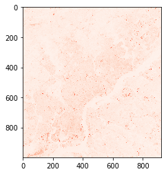

```python
# Red Channel
plt.imshow(landsat.read(3), cmap='Reds')
```

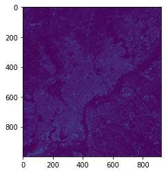

```python
# Near Infrared (NIR) Channel
plt.imshow(landsat.read(4))
```

### 1.2 Separating the city from the suburbs

Create two polygon objects, one for the city limits and one for the suburbs. To calculate the suburbs polygon, we will take everything outside the city limits but still within the bounding box.

```python
city_limits = gpd.read_file("./data/City_Limits.geojson")
```

```python
landsat.crs
```

```
CRS.from_dict(init='epsg:32618')
```

```python
#match the city limits crs with the landsat crs
city_limits = city_limits.to_crs(landsat.crs.data)
city_limits.crs
```

```
{'init': 'epsg:32618'}
```

```python
#find suburb polygon
suburbs = city_limits.envelope.difference(city_limits)
suburbs
```

```
0    MULTIPOLYGON (((481870.800 4413069.557, 476064...
dtype: geometry
```

### 1.3 Mask and calculate the NDVI for the city and the suburbs

Using the two polygons from the last section, use rasterio's mask functionality to create two masked arrays from the landsat data, one for the city and one for the suburbs.

For each masked array, calculate the NDVI.

```python
city, mask_transform = mask(
    dataset=landsat,
    shapes=city_limits.geometry,
    crop=True,
    all_touched=True,
    filled=False
)
```

```python
suburbs_m, mask_transform = mask(
    dataset=landsat,
    shapes=suburbs.geometry,
    crop=False,
    #invert=True, #can use this if did not calculate the suburbs polygon
    all_touched=True,
    filled=False
)
```

```python
city_red = city[3]
city_nir = city[4]
```

```python
suburbs_red = suburbs_m[3]
suburbs_nir = suburbs_m[4]
```

```python
#function to calculate NDVI
def calculate_NDVI(nir, red):
    nir = nir.astype(float)
    red = red.astype(float)

    # Get valid entries
    check = np.logical_and( red.mask == False, nir.mask == False )

    # Where the check is True, return the NDVI, else return NaN
    ndvi = np.where(check,  (nir - red ) / ( nir + red ), np.nan )
    return ndvi

NDVI_city = calculate_NDVI(city_nir, city_red)
NDVI_suburb = calculate_NDVI(suburbs_nir, suburbs_red)
```

### 2.1.4 Calculate the median NDVI within the city and within the suburbs

- Calculate the median value from your NDVI arrays for the city and suburbs
- Numpy's `nanmedian` function will be useful for ignoring NaN elements
- Print out the median values. Which has a higher NDVI: the city or suburbs?

```python
city_median = np.nanmedian(NDVI_city)
suburb_median = np.nanmedian(NDVI_suburb)
print('NDVI median for the city is ', city_median, ', NDVI median for the suburb is', suburb_median)
```

```
NDVI median for the city is  0.20268593532493442 , NDVI median for the suburb is 0.3746654463028859
```

A higher NDVI median for the suburb is not surprising: there are more live vegetation in the suburbs.

## 2 Calculating the NDVI for Philadelphia's street treets

### 2.1 Load the street tree data

The data is available in the "data/" folder. It has been downloaded from [OpenDataPhilly](https://www.opendataphilly.org/dataset/philadelphia-street-tree-inventory). It contains the locations of abot 2,500 street trees in Philadelphia.

```python
tree = gpd.read_file("./data/ppr_tree_canopy_points_2015.geojson")
tree.head()
```

|  | objectid | fcode | geometry |
| --- | --- | --- | --- |
| 0 | 1 | 3000 | POINT (-75.00538 40.06254) |
| 1 | 2 | 3000 | POINT (-75.12959 39.96692) |
| 2 | 3 | 3000 | POINT (-75.12838 39.98397) |
| 3 | 4 | 3000 | POINT (-75.12892 39.98489) |
| 4 | 5 | 3000 | POINT (-75.12948 39.97148) |

### 2.2 Calculate the NDVI values at the locations of the street trees

- Use the rasterstats package to calculate the NDVI values at the locations of the street trees.
- Since these are point geometries, I can calculate either median or mean statistic (only one pixel will contain each point), in this case, I calculated median.

```python
from rasterstats import zonal_stats
```

```python
#match the tree crs with landsat data
tree = tree.to_crs(landsat.crs.data)
tree.crs
```

```
{'init': 'epsg:32618'}
```

```python
tree_stats = zonal_stats(tree, NDVI_city, affine=landsat.transform, stats='median')
```

```python
tree_stats[0:10]
```

```
[{'median': 0.23533681765389083},
 {'median': 0.26153510526124424},
 {'median': 0.09676935199429665},
 {'median': 0.07662965738028744},
 {'median': 0.2679520805273978},
 {'median': 0.07685867381111855},
 {'median': 0.1051902048359772},
 {'median': 0.09178423236514523},
 {'median': 0.07616818902392995},
 {'median': 0.10229947492304907}]
```

### 2.3 Plotting the results

Make two plots of the results:

1. A histogram of the NDVI values, using matplotlib's `hist` function. Include a vertical line that marks the NDVI = 0 threshold
2. A plot of the street tree points, colored by the NDVI value, using geopandas' `plot` function. Include the city limits boundary on your plot.

```python
#change column name for the median calculated in the previous step
tree['median_NDVI'] = [s['median'] for s in tree_stats]
```

```python
tree.head()
```

|  | objectid | fcode | geometry | median_NDVI |
| --- | --- | --- | --- | --- |
| 0 | 1 | 3000 | POINT (499541.269 4434698.265) | 0.235337 |
| 1 | 2 | 3000 | POINT (488932.471 4424093.158) | 0.261535 |
| 2 | 3 | 3000 | POINT (489039.214 4425985.827) | 0.096769 |
| 3 | 4 | 3000 | POINT (488993.171 4426088.005) | 0.076630 |
| 4 | 5 | 3000 | POINT (488943.113 4424599.478) | 0.267952 |

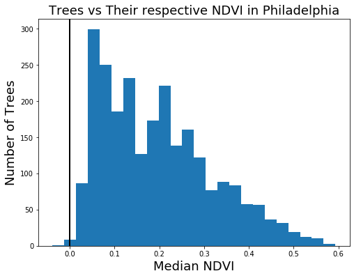

```python
fig, ax = plt.subplots(figsize=(8,6))

# Plot histogram
ax.hist(tree['median_NDVI'], bins='auto')
ax.axvline(x=0, c='k', lw=2)

ax.set_xlabel("Median NDVI", fontsize=18)
ax.set_ylabel("Number of Trees", fontsize=18);
ax.set_title("Trees vs Their respective NDVI in Philadelphia", fontsize=18);
```

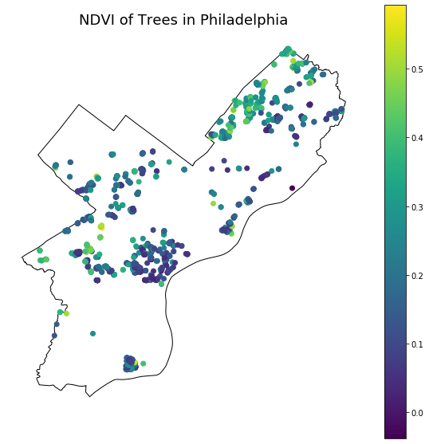

```python
fig, ax = plt.subplots(figsize=(10,10), facecolor='white')

# Plot the city limits
city_limits.plot(ax=ax, edgecolor='black', facecolor='none', linewidth=1)

# Plot the median NDVI
tree.plot(column='median_NDVI', legend=True, ax=ax)

ax.set_axis_off()
ax.set_title("NDVI of Trees in Philadelphia", fontsize=18);
```

The street trees in Philly mostly represent low NDVI based on the historgram. Spatially speaking, the North Eastern part and the West part of Philly have high NDVI. These regions represent the parks and suburbs. The rest of the regions have lower NDVI because those are the urban part with more housing and infrastructures.